# Proteomics_group_project_DATA_EXPLORATION

2025-11-13

DATA EXPLORATION:

```r
#install.packages("tidyverse")
library(tidyverse)
```

```r
library(dplyr)
library(ggplot2)
library(readr)
library(ComplexHeatmap)
#install.packages("circlize")
library(circlize)
# Install Bioconductor
#if (!require("BiocManager", quietly = TRUE))
#    install.packages("BiocManager")
#BiocManager::install(version = "3.21")

# Bioconductor option
#BiocManager::install("ComplexHeatmap")
```

# Introduction

## Background information: Abstract article

Patients with end-stage kidney disease (ESKD) are at high risk of severe COVID-19. Here, we perform longitudinal blood sampling of ESKD haemodialysis patients with COVID-19, collecting samples pre-infection, serially during infection and after clinical recovery. Using plasma proteomics, and RNA-sequencing and ow cytometry of immune cells, we identify transcriptomic and proteomic signatures of COVID-19 severity, and nd distinct temporal molecular pro les in patients with severe disease. Supervised learning reveals that the plasma proteome is a superior indicator of clinical severity than the PBMC transcriptome. We show that a decreasing trajectory of plasma LRRC15 (Leucine-rich repeat containing 15), a proposed co-receptor for SARS-CoV-2, is associated with a more severe clinical course. We observe that two months after the acute infection, patients still display dysregulated gene expression related to vascular, platelet and coagulation pathways, including PF4 (platelet factor 4), which may explain the prolonged thrombotic risk following COVID-19.

## Background information: Methodology

###Test subjects

All study objects were ESKD patients.

In the first COVID-19 wave: - Group of 53 patients infected with COVID-19 was selected - Group of 59 patients not infected with COVID-19 was selected as a negative control ->Serial blood sampling over a period of time

In the second COVID-19 wave: 17 patients in the negative controle groupe got infected with COVID-19 -> Also serial blood sampling. From these patients we have blood samples from a period the were negative and positive for COVID-19

### Plasma proteomics

The proteome is studied using the SomaScan assay (explained: https://www.youtube.com/watch?v=fg4mlG0nGLw), this technique measures the concentration of a set of target proteins. Modified aptamers = Somamers are used -> single stranded nucleic acid molecules with modified bases. These Somameres bind with high affinity to a specific protein, used as an alternative for antibodies, and are used to select a specific set of proteins. SomaScan v4.1 assay contains 7288 Somameres, 48 Somamers were removed due to QC failure, so the final dataset contains 7240 Somamers representing 6323 unique proteins.

Data Processing Protocol: 48 Somamers were removed due to QC failure, so the final post-QC dataset contained 7240 Somamers representing 6323 unique proteins. Where multiple Somamers related to the same protein, we retained these Somamers for univariate analyses such as differential abundance asnalyses. However, for analyses that considered multiple proteins simultaneously, we selected one Somamer at random to represent each protein. One COVID-19 positive sample in the wave 2 cohort failed QC and was excluded from the analyses. The expression values for each Somamer were inverse-rank normalised prior to downstream analyses. For the Wave 1 cohort, proteomic data were available for 86 samples from 37 COVID-19 positive ESKD patients (median 3 samples per patient, range 1-3), plus 53 non-infected ESKD patients. For the Wave 2 cohort (n = 17 patients), following QC, proteomic data were available for 102 samples collected serially during acute COVID-19 infection (median of 6 samples per patient, range 5–7) and 16 pre-infection samples. For one patient, a pre-infection plasma sample was unavailable. In the original manuscript (https://doi.org/10.1038/s41467-022-35454-4) we performed extensive downstream analysis. These included: i) differential protein abundance analyses comparing COVID-19 cases and controls; ii) differential protein abundance identifying associations with COVID-19 severity; iii) modelling of temporal protein profiles for both protein modules and 232 cytokines; and iv) prediction of COVID-19 severity from the proteome.

COVID positive Wave 1 53 - 16 = 37 COVID Negative Wave 1 59 - 6 = 53 COVID positive wave 2 17 -1 =16

#1 Importing data sets

```r
combined_dataset <- read.csv("combined_dataset.csv")
features_somameres <- read.csv("feature_meta.csv")
```

#2 Start of data exploration This function head() was used to display the first few rows of the dataset, providing a quick overview of the data structure and allowing us to verify that the dataset was loaded correctly.

```r
#head(combined_dataset)
#head(features_somameres)
```

the use of dim() is used to return the number of rows and columns, providing an overview of dataset size.

```r
dim(combined_dataset)
```

```
## [1]  241 7258
```

```r
dim(features_somameres)
```

```
## [1] 7240   15
```

splitting the ‘combined_dataset’ to seperate protein expression values from features

```r
combined_dataset_protein <-combined_dataset[,1:7241]
combined_dataset_features <-combined_dataset[,7242:7258]
```

colnames() to verify variable labels and ensure consistency in further analysis.

```r
colnames(combined_dataset_features)
```

```
##  [1] "individual_id"                 "ethnicity"
##  [3] "sex"                           "calc_age"
##  [5] "ihd"                           "previous_vte"
##  [7] "copd"                          "diabetes"
##  [9] "smoking"                       "cause_eskd"
## [11] "WHO_severity"                  "WHO_temp_severity"
## [13] "fatal_disease"                 "case_control"
## [15] "radiology_evidence_covid"      "time_from_first_symptoms"
## [17] "time_from_first_positive_swab"
```

```r
colnames(features_somameres)
```

```
##  [1] "soma_id"               "target_full_name"      "target"
##  [4] "uniprot"               "entrez_gene_id"        "entrez_gene_symbol"
##  [7] "dilution"              "col_check"             "uniprot_single"
## [10] "entrez_gene_id_single" "gene_id"               "converted_seq_ids"
## [13] "intracellular"         "membrane"              "secreted"
```

summary() produces basic descriptive statistics for each variable. This was also applied to the combined_dataset but removed due to excessive output size.

```r
summary(features_somameres)
```

```
##    soma_id          target_full_name      target            uniprot
##  Length:7240        Length:7240        Length:7240        Length:7240
##  Class :character   Class :character   Class :character   Class :character
##  Mode  :character   Mode  :character   Mode  :character   Mode  :character
##
##
##
##  entrez_gene_id     entrez_gene_symbol    dilution       col_check
##  Length:7240        Length:7240        Min.   : 0.005   Length:7240
##  Class :character   Class :character   1st Qu.:10.000   Class :character
##  Mode  :character   Mode  :character   Median :10.000   Mode  :character
##                                        Mean   : 8.327
##                                        3rd Qu.:10.000
##                                        Max.   :10.000
##  uniprot_single     entrez_gene_id_single   gene_id          converted_seq_ids
##  Length:7240        Length:7240           Length:7240        Length:7240
##  Class :character   Class :character      Class :character   Class :character
##  Mode  :character   Mode  :character      Mode  :character   Mode  :character
##
##
##
##  intracellular    membrane        secreted
##  Mode :logical   Mode :logical   Mode :logical
##  FALSE:1621      FALSE:5264      FALSE:5704
##  TRUE :5583      TRUE :1940      TRUE :1500
##  NA's :36        NA's :36        NA's :36
##
##
```

skimr() provides a more detailled summary, including missing values. Tested on the combined_dataset but excluded for the same reason as previous code.

```r
#install.packages("skimr")
library(skimr)
skim(features_somameres)
```

Data summary

| Name | features_somameres |
| --- | --- |
| Number of rows | 7240 |
| Number of columns | 15 |
| _______________________ |  |
| Column type frequency: |  |
| character | 11 |
| logical | 3 |
| numeric | 1 |
| ________________________ |  |
| Group variables | None |

**Variable type: character**

| skim_variable | n_missing | complete_rate | min | max | empty | n_unique | whitespace |
| --- | --- | --- | --- | --- | --- | --- | --- |
| soma_id | 0 | 1 | 8 | 8 | 0 | 6563 | 0 |
| target_full_name | 0 | 1 | 3 | 130 | 0 | 6562 | 0 |
| target | 0 | 1 | 2 | 42 | 0 | 6563 | 0 |
| uniprot | 0 | 1 | 6 | 20 | 0 | 6377 | 0 |
| entrez_gene_id | 0 | 1 | 0 | 32 | 3 | 6372 | 0 |
| entrez_gene_symbol | 0 | 1 | 2 | 20 | 0 | 6361 | 0 |
| col_check | 0 | 1 | 4 | 4 | 0 | 1 | 0 |
| uniprot_single | 0 | 1 | 6 | 6 | 0 | 6326 | 0 |
| entrez_gene_id_single | 0 | 1 | 0 | 32 | 3 | 6320 | 0 |
| gene_id | 0 | 1 | 2 | 14 | 0 | 6323 | 0 |
| converted_seq_ids | 0 | 1 | 10 | 13 | 0 | 7240 | 0 |

**Variable type: logical**

| skim_variable | n_missing | complete_rate | mean | count |
| --- | --- | --- | --- | --- |
| intracellular | 36 | 1 | 0.77 | TRU: 5583, FAL: 1621 |
| membrane | 36 | 1 | 0.27 | FAL: 5264, TRU: 1940 |
| secreted | 36 | 1 | 0.21 | FAL: 5704, TRU: 1500 |

**Variable type: numeric**

| skim_variable | n_missing | complete_rate | mean | sd | p0 | p25 | p50 | p75 | p100 | hist |
| --- | --- | --- | --- | --- | --- | --- | --- | --- | --- | --- |
| dilution | 0 | 1 | 8.33 | 3.64 | 0 | 10 | 10 | 10 | 10 | ▂▁▁▁▇ |

```r
skim
```

[output not shown]

str() is used to display the data types.

```r
str(features_somameres)
```

```
## 'data.frame':    7240 obs. of  15 variables:
##  $ soma_id              : chr  "SL019233" "SL002564" "SL019245" "SL019228" ...
##  $ target_full_name     : chr  "Beta-crystallin B2" "RAF proto-oncogene serine/threonine-protein kinase" "Zinc finger protein 41" "ETS domain-containing protein Elk-1" ...
##  $ target               : chr  "CRBB2" "c-Raf" "ZNF41" "ELK1" ...
##  $ uniprot              : chr  "P43320" "P04049" "P51814" "P19419" ...
##  $ entrez_gene_id       : chr  "1415" "5894" "7592" "2002" ...
##  $ entrez_gene_symbol   : chr  "CRYBB2" "RAF1" "ZNF41" "ELK1" ...
##  $ dilution             : num  10 10 0.5 10 10 10 10 10 10 10 ...
##  $ col_check            : chr  "PASS" "PASS" "PASS" "PASS" ...
##  $ uniprot_single       : chr  "P43320" "P04049" "P51814" "P19419" ...
##  $ entrez_gene_id_single: chr  "1415" "5894" "7592" "2002" ...
##  $ gene_id              : chr  "CRYBB2" "RAF1" "ZNF41" "ELK1" ...
##  $ converted_seq_ids    : chr  "seq.10000.28" "seq.10001.7" "seq.10003.15" "seq.10006.25" ...
##  $ intracellular        : logi  TRUE TRUE TRUE TRUE TRUE TRUE ...
##  $ membrane             : logi  FALSE FALSE FALSE FALSE FALSE FALSE ...
##  $ secreted             : logi  FALSE FALSE FALSE FALSE FALSE FALSE ...
```

```r
str(combined_dataset_features)
```

```
## 'data.frame':    241 obs. of  17 variables:
##  $ individual_id                : chr  "C101" "C101" "C101" "C101" ...
##  $ ethnicity                    : chr  "asian" "asian" "asian" "asian" ...
##  $ sex                          : chr  "M" "M" "M" "M" ...
##  $ calc_age                     : int  61 61 61 61 61 61 61 61 66 81 ...
##  $ ihd                          : chr  "yes.cabg" "yes.cabg" "yes.cabg" "yes.cabg" ...
##  $ previous_vte                 : chr  "no" "no" "no" "no" ...
##  $ copd                         : chr  "no" "no" "no" "no" ...
##  $ diabetes                     : chr  "yes.T2" "yes.T2" "yes.T2" "yes.T2" ...
##  $ smoking                      : chr  "not.current" "not.current" "not.current" "not.current" ...
##  $ cause_eskd                   : chr  "DN (bx or presumed)" "DN (bx or presumed)" "DN (bx or presumed)" "DN (bx or presumed)" ...
##  $ WHO_severity                 : chr  "" "severe" "severe" "severe" ...
##  $ WHO_temp_severity            : chr  "NEGATIVE" "moderate" "severe" "moderate" ...
##  $ fatal_disease                : chr  "" "False" "False" "False" ...
##  $ case_control                 : chr  "NEGATIVE" "POSITIVE" "POSITIVE" "POSITIVE" ...
##  $ radiology_evidence_covid     : chr  "" "yes:extensivebilateralairspaceconsolidation" "yes:extensivebilateralairspaceconsolidation" "yes:extensivebilateralairspaceconsolidation" ...
##  $ time_from_first_symptoms     : num  NA 7 10 12 14 0 2 5 NA NA ...
##  $ time_from_first_positive_swab: num  NA 11 14 16 18 4 6 9 NA NA ...
```

This code was applied to convert categorical variables from character to factor type (excluding protein_id), ensuring that these variables are properly recognized as discrete categories in statistical analyses.

```r
clinical_data <- c("ethnicity", "sex", "ihd", "previous_vte","copd", "diabetes", "smoking", "cause_eskd", "WHO_severity", "case_control","radiology_evidence_covid", "fatal_disease")
combined_dataset_features[clinical_data] <- lapply((combined_dataset_features[clinical_data]),factor)

# Convert the WHO_temp_severity column to a ranked column NEGATIVE = 1, mild = 2, moderate = 3, severe = 4, critical = 5
combined_dataset_features$WHO_temp_severity <- factor(
  combined_dataset_features$WHO_temp_severity,
  levels = c("NEGATIVE", "mild", "moderate", "severe", "critical"), ordered = TRUE)

# checking if data types changed correctly
str(combined_dataset_features)
```

```
## 'data.frame':    241 obs. of  17 variables:
##  $ individual_id                : chr  "C101" "C101" "C101" "C101" ...
##  $ ethnicity                    : Factor w/ 4 levels "asian","black",..: 1 1 1 1 1 1 1 1 1 3 ...
##  $ sex                          : Factor w/ 2 levels "F","M": 2 2 2 2 2 2 2 2 2 2 ...
##  $ calc_age                     : int  61 61 61 61 61 61 61 61 66 81 ...
##  $ ihd                          : Factor w/ 5 levels "no","unknown",..: 3 3 3 3 3 3 3 3 1 1 ...
##  $ previous_vte                 : Factor w/ 4 levels "no","yes.dvt",..: 1 1 1 1 1 1 1 1 1 1 ...
##  $ copd                         : Factor w/ 4 levels "bi","copd","no",..: 3 3 3 3 3 3 3 3 3 3 ...
##  $ diabetes                     : Factor w/ 3 levels "no","yes.T1",..: 3 3 3 3 3 3 3 3 3 1 ...
##  $ smoking                      : Factor w/ 5 levels "current","ex",..: 4 4 4 4 4 4 4 4 4 4 ...
##  $ cause_eskd                   : Factor w/ 6 levels "DN (bx or presumed)",..: 1 1 1 1 1 1 1 1 3 4 ...
##  $ WHO_severity                 : Factor w/ 5 levels "","critical",..: 1 5 5 5 5 5 5 5 1 1 ...
##  $ WHO_temp_severity            : Ord.factor w/ 5 levels "NEGATIVE"<"mild"<..: 1 3 4 3 4 4 4 4 1 1 ...
##  $ fatal_disease                : Factor w/ 3 levels "","False","True": 1 2 2 2 2 2 2 2 1 1 ...
##  $ case_control                 : Factor w/ 2 levels "NEGATIVE","POSITIVE": 1 2 2 2 2 2 2 2 1 1 ...
##  $ radiology_evidence_covid     : Factor w/ 11 levels "","cxr","no",..: 1 7 7 7 7 7 7 7 1 1 ...
##  $ time_from_first_symptoms     : num  NA 7 10 12 14 0 2 5 NA NA ...
##  $ time_from_first_positive_swab: num  NA 11 14 16 18 4 6 9 NA NA ...
```

```r
levels(combined_dataset_features$WHO_temp_severity)
```

```
## [1] "NEGATIVE" "mild"     "moderate" "severe"   "critical"
```

duplicated() applied to identify repeated entries within the dataset.

```r
duplicated_colnames1 <- duplicated(colnames(features_somameres))
true_values1 <- which(duplicated_colnames1)
true_values1
```

```
## integer(0)
```

```r
duplicated_colnames <- duplicated(colnames(combined_dataset_features))
true_values2 <- which(duplicated_colnames)
true_values2
```

```
## integer(0)
```

```r
duplicated_rownames <- duplicated(features_somameres)
true_values3 <- which(duplicated_rownames)
true_values3
```

```
## integer(0)
```

```r
duplicated_rownamess <- duplicated(combined_dataset_features)
true_values4 <- which(duplicated_rownamess)
true_values4
```

```
## integer(0)
```

integer(0) indicates that no duplicate entries were detected in the dataset

based on visual inspection of the dataset ‘feature_somameres’, suspicion arises that the column ‘col_check’ only has one value across all the rows, so this was verified using the following code.

```r
unique(features_somameres$col_check)
```

```
## [1] "PASS"
```

Previous suspicion was confirmed so this column is deleted. Since variables with only one constant value do not contribute any meaningful information to statistical analysis, the column was removed to reduce redundancy.

```r
feature_somameres <- features_somameres %>% select(-c(col_check))
head(feature_somameres)
```

```
##    soma_id                                   target_full_name target uniprot
## 1 SL019233                                 Beta-crystallin B2  CRBB2  P43320
## 2 SL002564 RAF proto-oncogene serine/threonine-protein kinase  c-Raf  P04049
## 3 SL019245                             Zinc finger protein 41  ZNF41  P51814
## 4 SL019228                ETS domain-containing protein Elk-1   ELK1  P19419
## 5 SL019234              Guanylyl cyclase-activating protein 1  GUC1A  P43080
## 6 SL014943                                           Beclin-1  BECN1  Q14457
##   entrez_gene_id entrez_gene_symbol dilution uniprot_single
## 1           1415             CRYBB2     10.0         P43320
## 2           5894               RAF1     10.0         P04049
## 3           7592              ZNF41      0.5         P51814
## 4           2002               ELK1     10.0         P19419
## 5           2978             GUCA1A     10.0         P43080
## 6           8678              BECN1     10.0         Q14457
##   entrez_gene_id_single gene_id converted_seq_ids intracellular membrane
## 1                  1415  CRYBB2      seq.10000.28          TRUE    FALSE
## 2                  5894    RAF1       seq.10001.7          TRUE    FALSE
## 3                  7592   ZNF41      seq.10003.15          TRUE    FALSE
## 4                  2002    ELK1      seq.10006.25          TRUE    FALSE
## 5                  2978  GUCA1A      seq.10008.43          TRUE    FALSE
## 6                  8678   BECN1      seq.10010.10          TRUE    FALSE
##   secreted
## 1    FALSE
## 2    FALSE
## 3    FALSE
## 4    FALSE
## 5    FALSE
## 6    FALSE
```

#3 Subsets data We create these subsets during our data exploration to isolate specific patient groups and better understand patterns related to case-control status and wave-specific characteristics.

```r
# Make a list with all the negative patients in the first wave
negatives_wave1 <- c()
for (i in 1:length(combined_dataset_features$case_control)){
  if (combined_dataset_features$case_control[i] == "NEGATIVE") {negatives_wave1 <- c(negatives_wave1, combined_dataset_features$individual_id[i])}
}

# Make a list with all the positive patients in the first wave
positives_wave1 <- c()
for (i in 1:length(combined_dataset_features$case_control)){
  id_in_negative_wave1 <- combined_dataset_features$individual_id[i] %in% negatives_wave1
  if (combined_dataset_features$case_control[i] == "POSITIVE" & id_in_negative_wave1 == FALSE) {
    id_in_positive_wave1 <- combined_dataset_features$individual_id[i] %in% positives_wave1
    if (id_in_positive_wave1 == FALSE){
      positives_wave1 <- c(positives_wave1, combined_dataset_features$individual_id[i])
    }
  }
}

# Make a list with all the positive patients in the second wave
positives_wave2 <- c()
for (i in 1:length(combined_dataset_features$case_control)){
  id_in_negative_wave1 <- combined_dataset_features$individual_id[i] %in% negatives_wave1
  if (combined_dataset_features$case_control[i] == "POSITIVE" & id_in_negative_wave1 == "TRUE"){
    id_in_positive_wave2 <- combined_dataset_features$individual_id[i] %in% positives_wave2
    if (id_in_positive_wave2 == FALSE){
      positives_wave2 <- c(positives_wave2, combined_dataset_features$individual_id[i])
    }
  }
}

# Features Wave 1 COVID negative patients
features_wave1_COVID_negative <- combined_dataset_features %>% filter(case_control == "NEGATIVE")
```

#4 Paired samples per individual grouping the data by individual to assess how many measurements each patient has

```r
# How many samples are taken from each patient
combined_dataset %>%
  group_by(individual_id) %>%
  summarise(n_samples = n())
```

```
## # A tibble: 91 × 2
##    individual_id n_samples
##    <chr>             <int>
##  1 C101                  8
##  2 C103                  1
##  3 C104                  1
##  4 C106                  1
##  5 C108                  7
##  6 C110                  1
##  7 C113                  3
##  8 C116                  3
##  9 C123                  3
## 10 C124                  3
## # ℹ 81 more rows
```

#5 Missing values

checking for missing values in the combined dataset

```r
combined_dataset[combined_dataset == ""] <- NA

# Missing values summary
missing_summary <- combined_dataset%>%
  summarise(across(everything(), ~ sum(is.na(.)))) %>%
  pivot_longer(cols = everything(), names_to = "Variable", values_to = "Missing_Values") %>%
  mutate(Missing_Percentage = (Missing_Values / nrow(combined_dataset)) * 100) %>%
  arrange(desc(Missing_Percentage))

#looking at the top 20 of missing_summary
head(missing_summary, 20)
```

```
## # A tibble: 20 × 3
##    Variable                      Missing_Values Missing_Percentage
##    <chr>                                  <int>              <dbl>
##  1 time_from_first_symptoms                  82               34.0
##  2 WHO_severity                              53               22.0
##  3 fatal_disease                             53               22.0
##  4 radiology_evidence_covid                  53               22.0
##  5 time_from_first_positive_swab             53               22.0
##  6 X                                          0                0
##  7 CRYBB2                                     0                0
##  8 RAF1                                       0                0
##  9 ZNF41                                      0                0
## 10 ELK1                                       0                0
## 11 GUCA1A                                     0                0
## 12 BECN1                                      0                0
## 13 OCRL                                       0                0
## 14 SPDEF                                      0                0
## 15 SNAI2                                      0                0
## 16 KCNAB2                                     0                0
## 17 POLH                                       0                0
## 18 VDR                                        0                0
## 19 HOGA1                                      0                0
## 20 DLD                                        0                0
```

```r
# Barplot of percentage missing per variable
missing_summary %>%
  filter(Missing_Values > 0) %>%  # selecting only missing values
  ggplot(aes(x = reorder(Variable, Missing_Percentage), y = Missing_Percentage)) +
  geom_col(fill = "steelblue") +
  coord_flip() +
  labs(title = "Percentage of Missing Values by Variable",
       x = "Variable",
       y = "Percentage of Missing Values") +
  theme_minimal()
```

[figure not shown]

```r
is.na
```

```
## function (x)  .Primitive("is.na")
```

INTERPRETATION: The missing values have been examined and we note that in WHO_severity, fatal_disease, radiology_evidence_covid and time_from_first_positive_swab there are each 53 missing values. This could indicate that 53 individuals consistently have a missing value in these columns.We will investigate this further by transposing data and calculating the percentage of missing value per person.

```r
# transpose the data (column becomes row and vice versa)
transposed_df <- t(combined_dataset_features)
transposed_df <- as.data.frame(t(combined_dataset_features))

# calculate the percentage of missing value per person
missing_summary <- transposed_df %>%
  summarise(across(everything(), ~ sum(is.na(.)))) %>%   # number of NAs per column
  pivot_longer(cols = everything(),
               names_to = "Variable",
               values_to = "Missing_Values") %>%
  mutate(Missing_Percentage = (Missing_Values / ncol(transposed_df)) * 100) %>%  # number of examples
  arrange(desc(Missing_Percentage))


missing_summary
```

```
## # A tibble: 241 × 3
##    Variable Missing_Values Missing_Percentage
##    <chr>             <int>              <dbl>
##  1 V1                    2              0.830
##  2 V9                    2              0.830
##  3 V10                   2              0.830
##  4 V11                   2              0.830
##  5 V12                   2              0.830
##  6 V42                   2              0.830
##  7 V46                   2              0.830
##  8 V47                   2              0.830
##  9 V54                   2              0.830
## 10 V61                   2              0.830
## # ℹ 231 more rows
```

#6 Data outliers Finding out how the protein abundances are distributed and if there are big outliers

```r
# Pivot the protein abundances dataframe (combindes_dataset_protein) to a longer dataframe
pivot_longer_proteins <- combined_dataset_protein %>%
  pivot_longer(!X, names_to = "prots", values_to = "abundances")

# Visualisation of the distribution of the protein abundances
pivot_longer_proteins %>%
  ggplot(aes(x = abundances))+
  geom_histogram(binwidth = 5000)+
  theme_classic()+
  labs(title = "Distribution protein abundances")
```

[figure not shown]

```r
# Identify outliers based on a boxplot
pivot_longer_proteins %>%
  ggplot(aes(x = abundances))+
  geom_boxplot()+
  theme_classic()+
  labs(title = "Boxplot protein abundances")
```

[figure not shown]

INTERPRETATION: The histogram and box plot of all protein abundances clearly show a large number of outliers, with a long tail to the right. To make this data less skewed, we will try implement a cut-off value

```r
# Calculate the median, and the standard deviation for the protein abundances. This will be used to set a cut of value.
sd_prot_abundances <- sd(pivot_longer_proteins$abundances)
median_prot_abundances <- median(pivot_longer_proteins$abundances)

cat("median protein abundance: ", median_prot_abundances, "\n",
    "sd protein abundance: ", sd_prot_abundances)
```

```
## median protein abundance:  769.4
##  sd protein abundance:  15642.3
```

```r
# We will use the median+ 2sd as cut of, and see how many outliers remain
cut_of <- median_prot_abundances + 2 * sd_prot_abundances

pivot_longer_proteins_cut_of <- pivot_longer_proteins %>%
  filter(abundances <= cut_of)

# Visualisation of the distribution of the protein abundances
pivot_longer_proteins_cut_of %>%
  ggplot(aes(x = abundances))+
  geom_histogram(binwidth = 100)+
  theme_classic()+
  labs(title = "Distribution protein abundances below cut of")
```

[figure not shown]

```r
# Identify outliers based on a boxplot
pivot_longer_proteins_cut_of %>%
  ggplot(aes(x = abundances))+
  geom_boxplot()+
  theme_classic()+
  labs(title = "Boxplot protein abundances below cut of")
```

[figure not shown]

INTERPRETATION: The histogram and boxplot indicate that there is still a large number of outliers present. Although applying a cut-off value reduces the number of outliers, we will proceed without using the cut-off to avoid introducing bias into the analysis.

#7 Filtering

The goal of filtering is to investigate if there are proteins or patient-meta data that has almost no variation.

#7.1 Filtering patient-meta data

```r
# We first count how often each category occurs. Then, we take the most common category and divides it by the total number of people. This tells you what percentage of the dataset consists of the largest category. If the dominance is higher than 80%, you know that one category strongly dominates, and therefore there is little variation.

dominantie <- function(x){
  tb <- table(x)
  max(tb) / sum(tb) * 100
}

sapply(combined_dataset_features[2:17], dominantie)
```

```
##                     ethnicity                           sex
##                     51.037344                     65.145228
##                      calc_age                           ihd
##                      7.053942                     50.622407
##                  previous_vte                          copd
##                     95.850622                     92.531120
##                      diabetes                       smoking
##                     61.410788                     85.892116
##                    cause_eskd                  WHO_severity
##                     55.186722                     28.630705
##             WHO_temp_severity                 fatal_disease
##                     41.908714                     62.655602
##                  case_control      radiology_evidence_covid
##                     78.008299                     29.045643
##      time_from_first_symptoms time_from_first_positive_swab
##                      9.433962                     14.361702
```

INTERPRETATION: Based on this code we notice that previous_vte, copd and smoking have a low variation and are therefore not very informative.

#7.2 Filtering proteins

```r
# proteins with a coefficient_of_variance lower than 10%
low_variance <- combined_dataset_protein %>%
  pivot_longer(!X, names_to = "prots", values_to = "abundances") %>%
  group_by(prots) %>%
  summarise(coefficient_of_variance = sd(abundances, na.rm = TRUE) / mean(abundances, na.rm = TRUE) * 100) %>%
  arrange(desc(coefficient_of_variance))
low_variance
```

```
## # A tibble: 7,240 × 2
##    prots   coefficient_of_variance
##    <chr>                     <dbl>
##  1 FNDC4                     1117.
##  2 KCTD7                      944.
##  3 BRAT1                      934.
##  4 HMGCR                      882.
##  5 ATF5                       815.
##  6 MORF4L1                    745.
##  7 MSLN                       740.
##  8 PVRIG                      729.
##  9 RBM41                      724.
## 10 ENTPD2                     718.
## # ℹ 7,230 more rows
```

INTERPRETATION: The data is analyzed for cases and controls. It is important to note that a person in WAVE 1 could have been considered a control, but later developed COVID-19 and is therefore included as a case in WAVE 2. We opted to analyse all samples independently and treat each sample as a separate observation. As a result, biological variation within individuals is not accounted for. We chose to proceed with patient-independent analyses for consistency with the dataset structure, but we acknowledge this limitation and consider it when interpreting the results.

#8 Normalisation The paper reports the following: “The expression values for each Somamer were inverse-rank normalised prior to downstream analyses.” However, it is not specified whether the dataset we received contains the raw expression values or values that have already undergone this normalisation. Therefore, our first step will be to determine whether additional normalisation is required.

```r
# total per sample
# Sum the values in each row of your df. The NA values are ignored. Sample total is a vector with a length equal to the number of samples, where each value is the total protein intensity per sample.
sample_totals <- rowSums(combined_dataset_protein [2:7241], na.rm=TRUE)

# plot
qplot(1:length(sample_totals), sample_totals) +
  labs(x="sample index", y="Total protein intensity / sample") +
  geom_hline(yintercept = median(sample_totals), linetype="dashed")
```

[figure not shown]

INTERPRETATION: In this figure, we compared the total intensity per sample. The median is the average value of all intensities. We would therefore expect all values to roughly converge around this dotted line, but that is not the case. Some samples are much higher or lower than others, meaning normalisation is necessary.

We selected a random protein, such as LRRC15, and noticed that its abundance is not normally distributed, which necessitates the use of a log transformation. To evaluate the effect of this transformation, we generated histograms for a single protein before and after log transformation. This comparison illustrates the change in distribution. Following this assessment, the log transformation was applied to all protein measurements.

histogram BEFORE transformation

```r
ggplot(combined_dataset_protein, aes(x = combined_dataset_protein$LRRC15)) +
  geom_histogram(bins = 100, fill = "steelblue", color = "black", aplha = 0.7) +
  labs(title = "Histogram of LRRC15 before log-transformation",
       x = "LRRC15 protein abundance", y = "Frequency") +
  theme_minimal()
```

[figure not shown]

histogram AFTER transformation

```r
ggplot(combined_dataset_protein, aes(x = log(combined_dataset_protein$LRRC15))) +
  geom_histogram(bins = 100, fill = "steelblue", color = "black", aplha = 0.7) +
  labs(title = "Histogram of LRRC15 after log-transformation",
       x = "LRRC15 Protein concentration", y = "Frequency") +
  theme_minimal()
```

[figure not shown]

Log transformation of all data:

```r
# Normalise protein abundance
proteins_log <- log(combined_dataset_protein[,2:7241])
```

Visualisation after the log tansformation:

```r
log_sample_totals <- rowSums(proteins_log, na.rm=TRUE)

# plot
qplot(1:length(log_sample_totals), log_sample_totals) +
  labs(x="sample index", y="Total protein intensity / sample") +
  geom_hline(yintercept = median(log_sample_totals), linetype="dashed")
```

[figure not shown]

INTERPRETATION: The normalisation appears to be successful, as the values now fall within a narrow range of approximately 50,000–52,000. In addition, the distribution shows greater symmetry around the mean, and large systematic differences between samples have been eliminated.

#9 Standarisation Standardisation is applied to ensure that all proteins are placed on a comparable scale before visualisation. Because proteins can vary greatly in their absolute abundance, these differences could dominate the heatmap and obscure meaningful patterns. By standardising the log-transformed protein values, we emphasise relative variation across samples, allowing clearer identification of clusters and expression patterns. A heatmap of the non-standardised data is shown first to visualise the raw differences, followed by a heatmap of the standardised data to demonstrate how standardisation improves comparability across proteins.

```
## The automatically generated colors map from the 1^st and 99^th of the
## values in the matrix. There are outliers in the matrix whose patterns
## might be hidden by this color mapping. You can manually set the color
## to `col` argument.
##
## Use `suppressMessages()` to turn off this message.
```

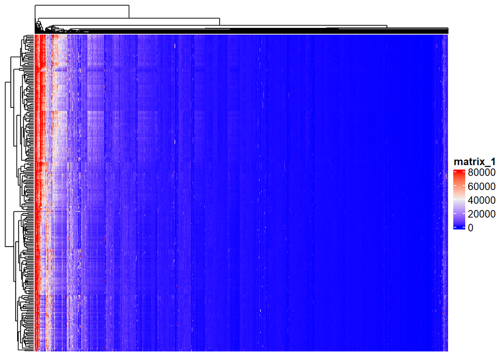

```r
# Standardise protein abundance
protein_scaled <- as.data.frame(scale(proteins_log))

# heatmap non-standardisised protein abundances
Heatmap(combined_dataset_protein %>% column_to_rownames("X")  , use_raster = FALSE, show_row_names = FALSE, show_column_names = FALSE)
```

```
## The automatically generated colors map from the minus and plus 99^th of
## the absolute values in the matrix. There are outliers in the matrix
## whose patterns might be hidden by this color mapping. You can manually
## set the color to `col` argument.
##
## Use `suppressMessages()` to turn off this message.
```

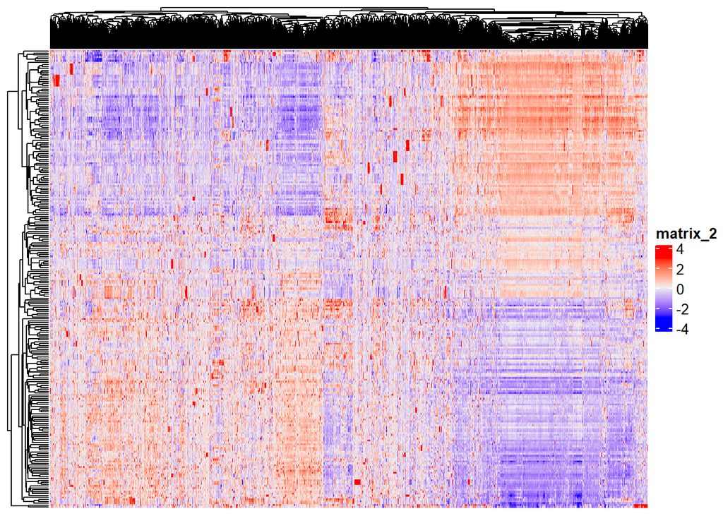

```r
# heatmap standarsised protein abundances
Heatmap(protein_scaled, use_raster = FALSE, show_row_names = FALSE, show_column_names = FALSE)
```

```
## The automatically generated colors map from the minus and plus 99^th of
## the absolute values in the matrix. There are outliers in the matrix
## whose patterns might be hidden by this color mapping. You can manually
## set the color to `col` argument.
##
## Use `suppressMessages()` to turn off this message.
```

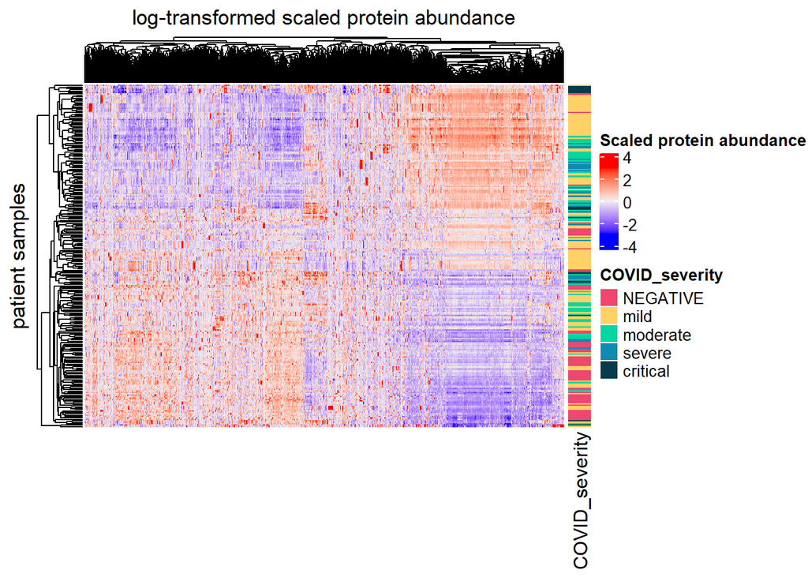

```r
# heatmap standarsised protein abundances + row annotations on WHO_temp_severity
annotation_WHO_temp_severity = rowAnnotation(COVID_severity = combined_dataset_features$WHO_temp_severity,
                                             col = list(COVID_severity = c("NEGATIVE"="#ef476f", "mild"="#ffd166", "moderate"="#06d6a0", "severe"="#118ab2", "critical"="#073b4c" )))
Heatmap(protein_scaled, name="Scaled protein abundance", use_raster = FALSE, show_row_names = FALSE, show_column_names = FALSE, right_annotation = annotation_WHO_temp_severity,column_title = "log-transformed scaled protein abundance", row_title = "patient samples")
```

#10 DEA Find the protein that is most differentially expressed in the COVID-cases, in comparison with the negative controls. We will visualise this with a vulcano plot

```r
#if (!requireNamespace("BiocManager", quietly = TRUE))
#    install.packages("BiocManager")

#BiocManager::install("edgeR")
library(edgeR)
```

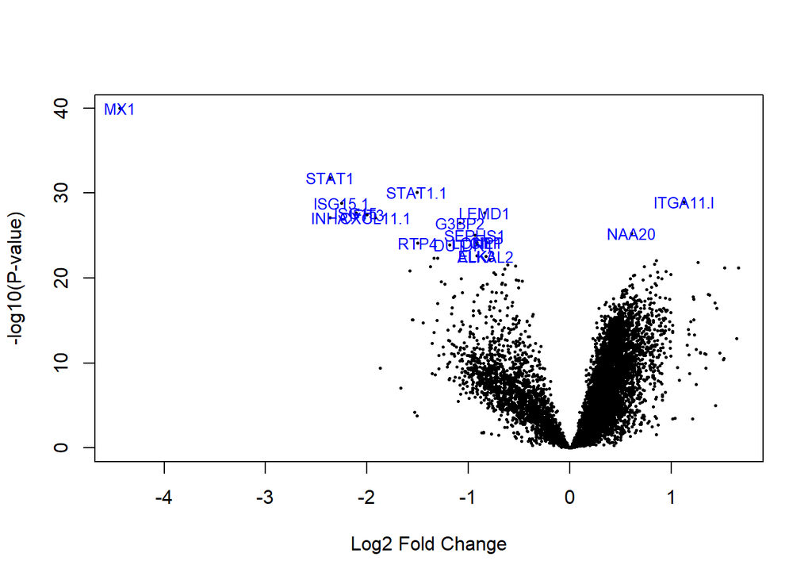

```r
# transpose the combined_dataset_protein, this is needed for a DEA.
n <- combined_dataset_protein$X
transposed_proteins <- as.data.frame(t(combined_dataset_protein[,-1]))
colnames(transposed_proteins) <- n

# Make a DEA matrix, and log transform it
counts_matrix <- as.matrix(transposed_proteins)
dge <- DGEList(counts = counts_matrix, group = combined_dataset_features$case_control)
log_voom_matrix <- voom(dge)

# Design and contrast matrix
design <- model.matrix(~0 + case_control, data=combined_dataset_features)

# Define the contrast
contrast.matrix_negpos <- makeContrasts(contrast1=case_controlNEGATIVE-case_controlPOSITIVE, levels=design)


## Fit model & perform differential expression
#fitting the expression matrix to linear models
fit <- lmFit(log_voom_matrix, design)
#compute contrast
fit_negpos <- contrasts.fit(fit, contrast.matrix_negpos)
#Bayes statistic of differential expression
fit_negpos <- eBayes(fit_negpos)

volcanoplot(fit_negpos, coef=1, highlight = 20, names=rownames(fit_negpos))
```